# Mapping zipcodes

Steve Simon

July 16, 2018

```r
library(sf)
library(tidyverse)
```

You can find the shapefiles for zipcodes at [the U.S Census website](https://www.census.gov/geo/maps-data/data/cbf/cbf_zcta.html).

The census files use a shapefile format. This is a rather complex system with at least three separate files constituting the shapefile. You can find a nice introduction at the [Wikipedia page on shapefiles](https://en.wikipedia.org/wiki/Shapefile).

The st_read function is part of the sf library. It reads a shape file and converts it to an sf object. An sf (simple features object) is a data frame where the last column is a list-column, an sfc object.

The list column represents geographic features either as a single data points (POINT), multiple data points (MULITPOINT), a two-dimensional path (LINESTRING), multiple paths (MULTILINESTRING), a polygon (POLYGON), or multiple polygons (MULTIPOLYGON).

The POLYGON and MULTIPOLYGON features can include holes, and there are complex rules for geographic features with holes.

```r
path_name <- "~/zipcode-example/data"
list.files(path_name)
```

```
##  [1] "cb_2017_us_zcta510_500k.cpg"
##  [2] "cb_2017_us_zcta510_500k.dbf"
##  [3] "cb_2017_us_zcta510_500k.prj"
##  [4] "cb_2017_us_zcta510_500k.shp"
##  [5] "cb_2017_us_zcta510_500k.shp.ea.iso.xml"
##  [6] "cb_2017_us_zcta510_500k.shp.iso.xml"
##  [7] "cb_2017_us_zcta510_500k.shp.xml"
##  [8] "cb_2017_us_zcta510_500k.shx"
##  [9] "plot-zips.RData"
## [10] "what belongs in data folder.txt"
```

```r
file_name <- "cb_2017_us_zcta510_500k.shp"
path_name                              %>%
  paste(file_name, sep="/")            %>%
  st_read(stringsAsFactors=FALSE)      -> all_zipcodes
```

The sf object looks and acts like an ordinary data frame. But the last column is quite unusual.

```r
names(all_zipcodes)
```

```
## [1] "ZCTA5CE10"  "AFFGEOID10" "GEOID10"    "ALAND10"    "AWATER10"
## [6] "geometry"
```

WARNING!! The geom_sf function in ggplot2 is experimental and not yet part of the regular package (at least not at the time I wrote this, February 2018). You have to install a special version of ggplot2 using the RTools package. For details, go to

https://dcl-2017-01.github.io/curriculum/notes/spatial-vis.html

and note the installation instructions at the very top of the page.

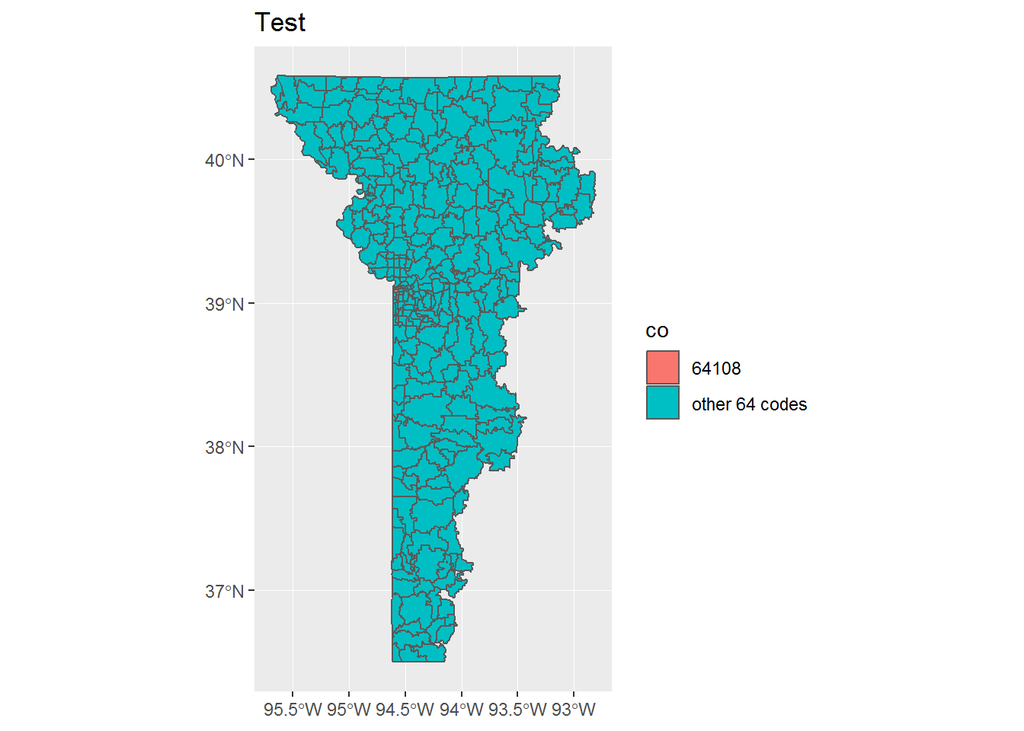

```r
all_zipcodes                           %>%
  filter(grepl("^64", GEOID10))        %>%
  mutate(co=ifelse(GEOID10=="64108", "64108", "other 64 codes")) %>%
  ggplot()                              +
  geom_sf(aes(fill=co))                 +
  ggtitle("Test")
```

Save everything for possible later use.

```r
save.image("~/zipcode-example/data/plot-zips.RData")
```